# QGIS Training

# 1 Welcome to ForestPlots course on digital data collection!

This course aims at providing principal researchers and field leaders the tools to collect data digitally in the field. It relies on QGIS and QField softwares, respectfully for computers and tablets.

For this course, you will need: * a computer running on Windows, ideally Windows 11 (this training is not yet available for Mac users) * an Android tablet * a cable to link the computer and the tablet (usually USB-A and USB-C, or double USB-C) * an internet connection

*Can everyone please introduce their experience with digital data collection or data collection in general?*

## Advantages and Risks of a Tablet

*Can everyone please share the advantages and risks they could face with digital data collection?*

| Advantages | Risks |
| --- | --- |
| Time saver | Misoneism |
| Less prone to error | Electronic waste |
| Workflow more fluid | Cost |
| More flexible | Data loss (including theft) |
| Less paper | Difficult access to electricity |
| Data spatialisation |  |

## Summary of Digital Data Collection

Now that we are aware of the advantages and risks of digital data collection, we can start the technical training, structured around the main components of digital data collection:

[figure not shown]

# I One time set up

# 2 Accessing ForestPlots

When re-censusing a plot, you need access to the data from the previous censuses in order to make a field sheet, find the plot, and collect the data. You can find everything you need on ForestPlots.net.

## What is ForestPlots?

ForestPlots.net is a database where you can securely store, manage and analyse tropical forest plot data.

[figure not shown]

ForestPlots.net stores and serves stem data and metadata for multi- and single-census plots in forests and savannas, including trees, lianas, species, demography, traits and soils.

## How to access ForestPlots data?

In order to access the ForestPlots data, you must

1. Read the [code of conduct](https://forestplots.net/en/join-forestplots/code-of-conduct),
2. Register to have an account on ForestPlots [here](https://forestplots.net/en/join-forestplots/user-gui), and
3. Email the associated country data officer to ensure the account is granted and to receive the necessary training to use ForestPlots. *Note: Nika Gorski is the data officer for Africa data.*

Only once you have completed these steps will you be able to access data to ForestPlots and produce field sheets.

If you haven’t fully completed these steps, you can still move on to `Module 3 and 4` to install the necessary software on your laptop and tablet.

# 3 How to set up your laptop

Whether you have a ForestPlots account, you now need to set up your computer and your tablet. Your will use your computer to create the surveys and your tablet to execute them. While seemingly boring, the next steps are crucial: if executed properly, they will save us a tremendous amount of issues. Therefore, please take your time so we can stay organised from the beginning.

[QGIS](https://qgis.org/) is a geographic information system software. In order to install QGIS on your computer, please follow these steps:

**1.** Click [here](https://qgis.org/download/) to access the download package. If you feel generous, you can make a contribution to QGIS or skip to download (orange button *Skip it and go to download*).

[figure not shown]

**2.** Once you passed the donation page, download the most recent **Long Term Release** (currently **Download LTR 3.40**). Do not download the *Latest release*, it is not needed for what we do and is more likely to come with bugs.

[figure not shown]

**3.** Once you have downloaded the QGIS installation file, open it and follow the instructions. We advise you to keep the default and recommended set-up options.

**4.** Congratulations, you have installed QGIS on your computer! You can now launch it (be patient, QGIS may take some time to launch) and should soon see a similar interface:

[figure not shown]

**5.** Click on the *Extensions* menu and select *Installer/Gérer les extensions*.

[figure not shown]

**6.** Type ‘QField Sync’ in the research bar of the pop-up window.

[figure not shown]

**7.** Tick the box near *QField Sync*, just below the research bar, and close the pop-up window.

[figure not shown]

**8.** Click on the *Extensions* menu, a *QField Sync* sub-menu should now be present.

[figure not shown]

# 4 How to set up your tablet

[QField](https://qfield.org/) is an open-access application for spatial data collection and edition. Here, we assume that you already set up your tablet with a Google account that grants you access to the Google Play Store. In order to install QField on your tablet, please follow these steps:

**1.** Go to the tablet homepage.

[figure not shown]

**2.** Open the Play Store.

**3.** Click on the *Sign in* symbol.

[figure not shown]

**4.** Either sign in with your own Google account (not recommended) or create an account with a clear name and address. For instance, you can paste the name of your project and country or institution. Choose a secured password that you are also able to remember. It is good to store it somewhere safe and share it with a couple of colleagues.

[figure not shown]

**5.** Welcome to the Play Store, you can click on *Not now*.

[figure not shown]

**6.** Type ‘qfield’ in the research bar.

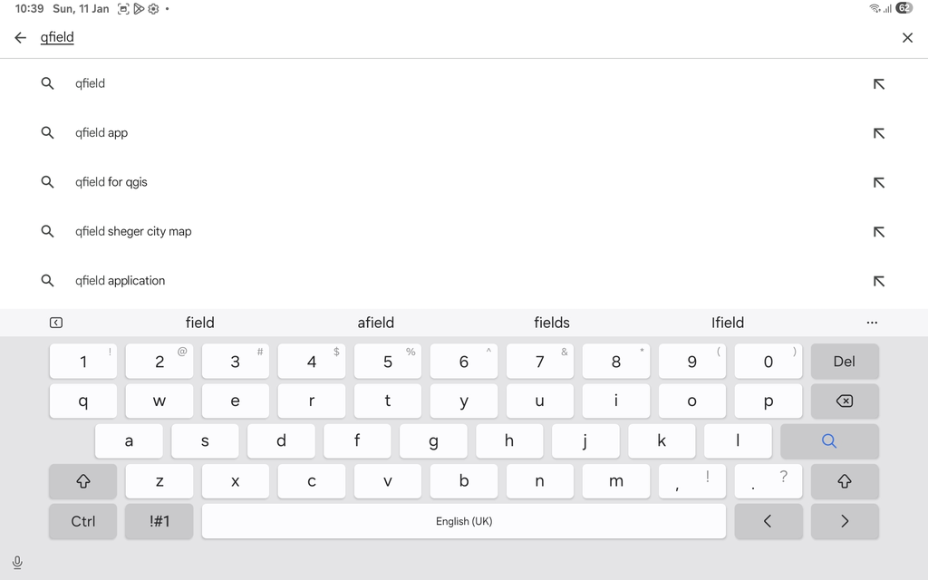

**7.** Click on QField symbol and then *Install* it.

[figure not shown]

**8.** Once installed, *Open* QField.

[figure not shown]

**9.** Welcome to QField, your computer and tablet configuration is over, we can now start collecting data!

[figure not shown]

# 5 Tablet to Laptop (Vice Versa)

#### Learning objectives

- Move documents from your laptop onto your tablet
- Move documents from your tablet onto your laptop

One of the most important steps for collecting data digitally is to be able to access your data. So before diving in to collect data and create a QField project, let’s learn how to move documents between your two devices.

**1.** Create a folder on your computer called `QGIS_training`, and save this folder somewhere that you know how to get to and will navigate to often.

**2.** Save this a picture of a very common tree in the Republic of Congo into your `QGIS_training` folder: moabi_tree.png. Do you know what kind of tree it is?

**3.** Connect your tablet to your computer via the cable.

**4.** In your files on the bottom left of your screen, you will see a new device appear. For example, in the image below when an `Apple iPad` was plugged into the device, it appeared.

[figure not shown]

**5.** Copy your `QGIS_training` folder.

**6.** Paste your `QGIS_training` folder into the tablet area of your device.

**7.** Disconnect your tablet from your computer. Is the image on your tablet?

**8.** This time download a pdf document and save it to your computer and move it to the tablet: ForestPlot Codes. When you are done, disconnect the tablet from the laptop and check that the pdf is on your tablet.

**9.** Now to move a document from the tablet to your computer, you do the same thing but in reverse. With your tablet disconnected from your computer, take a photo of your neighbor (with their permission) and save it to your `QGIS_training` folder with their name.

**10.** Connect your laptop and tablet via the cable and move the image from the tablet’s `QGIS_training` folder into the `QGIS_training` folder on your laptop.

**11** Disconnect your laptop and tablet. On your computer do you have an image of a tree, a pdf, and an image of your neighbor in your `QGIS_training` folder?

And that’s how to move documents between your laptop and tablet.

# II **Data Collection via QGIS**

# 6 Using QField survey

In the last sections, you learnt about ForestPlots, installed [QGIS](https://qgis.org/) on your computer and [QField](https://qfield.org/) on your field tablet. It is now time to learn how to collect data in the field using QField.

Your tablets have been pre-loaded with a QField survey so you can have directly have a hands-on experience. Here is you get access to it:

**1.** Go to the application menu and open QField.

[figure not shown]

**2.** Click *Local projects and datasets*.

[figure not shown]

**3.** An access window will pop-up the first time you use QField. Select *Allow all*.

[figure not shown]

**4.** Click on the green button in the bottom right corner.

[figure not shown]

**5.** Click on *Import project from folder* in the pop-up menu.

[figure not shown]

**6.** Click on `qgis_training_example1` folder.

[figure not shown]

**7.** Click on *Use this folder*.

[figure not shown]

**8.** Click on *Allow* on the pop-up window.

[figure not shown]

**9.** Click on `qgis_training_example1_qfield`.

[figure not shown]

**10.** Here is your plot to inventory, you can click on tree number 1.

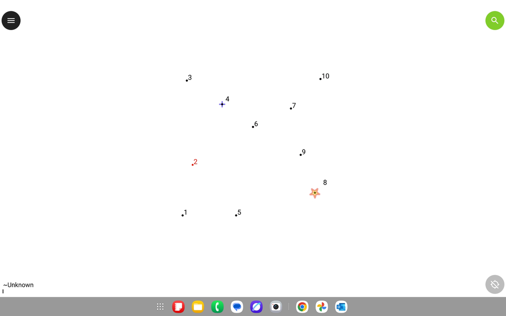

**11.** Click on *1* in the right-hand panel.

[figure not shown]

**12.** Click on the pencil symbol in the top-right corner, you can start typing data in!

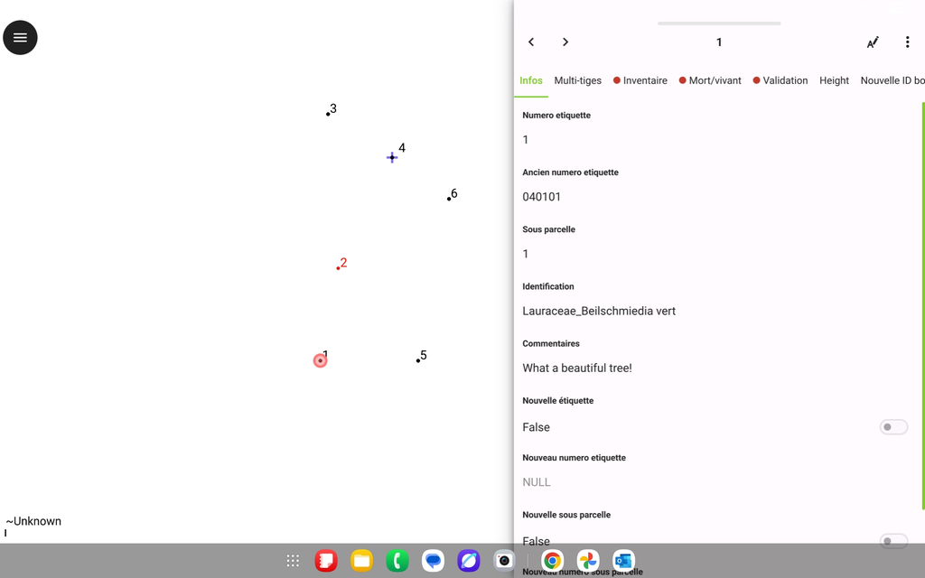